# Using NHANES 2017-18 Data to Observe How Work Life Affects BMI

# 1 Setup and Ingest

```r
library(ggrepel)
library(mosaic)
library(equatiomatic)
library(car)
library(GGally)
library(knitr)
library(patchwork)
library(haven)
library(naniar)
library(broom)
library(janitor)
library(magrittr)
library(tidyverse)

set.seed(20211206)
```

Ingesting study2 table that was developed in another RMarkdown file.

```r
study2_raw <- read_rds("data/NHANES_study2.Rds")
```

# 2 Clean Data

Filtered the raw table to only include desired variables and age group before cleaning individual variables.

```r
study2_raw <- study2_raw %>%
  select(SEQN, RIDAGEYR, RIDSTATR, BMXBMI, OCQ180, OCQ670, DBD895, CBD071, INDHHIN2) %>%
  filter(complete.cases(.),
         RIDAGEYR >= 18 & RIDAGEYR <= 65)
```

Before fully cleaning the data, I looked at numerical summaries of quantitative variables, as well as counts and proportions for categorical variables. The first table below shows some max values that are coded as a double value, however they actually represent individuals who either could not answer or refused to respond. For the sake of this analysis, these values are going to be coded as missing, and missingness is assumed to be completely at random. For this reason, a complete case analysis will be performed.

```r
df_stats(~ BMXBMI + OCQ180+DBD895+CBD071, data = study2_raw)
```

```
  response  min    Q1 median     Q3      max        mean           sd    n
1   BMXBMI 15.5  24.5   28.4  33.20     68.2    29.56822     7.262086 2574
2   OCQ180  5.0  35.0   40.0  47.75  99999.0   186.57770  3738.624994 2574
3   DBD895  0.0   1.0    3.0   5.00   9999.0    21.67832   408.637825 2574
4   CBD071  0.0 215.5  400.0 600.00 999999.0 10022.77545 95307.359636 2574
  missing
1       0
2       0
3       0
4       0
```

Table below shows counts and percents for the categorical variable `OCQ670`. This variable corresponds to overall work schedule for the past 3 months. **Note** that 7 and 9 are to be counted as missing values.

```r
study2_raw %>% tabyl(OCQ670)
```

```
 OCQ670   n      percent
      1 961 0.3733488733
      2 337 0.1309246309
      3 391 0.1519036519
      5 883 0.3430458430
      7   1 0.0003885004
      9   1 0.0003885004
```

```r
study2_raw %>% tabyl(INDHHIN2)
```

```
 INDHHIN2   n    percent
        1  50 0.01942502
        2  39 0.01515152
        3  64 0.02486402
        4 113 0.04390054
        5 125 0.04856255
        6 221 0.08585859
        7 269 0.10450660
        8 197 0.07653458
        9 192 0.07459207
       10 148 0.05749806
       12 108 0.04195804
       13  28 0.01087801
       14 296 0.11499611
       15 616 0.23931624
       77  41 0.01592852
       99  67 0.02602953
```

In the code below, I am performing all of the necessary cleaning required for the data set. All labels are zapped from the variables and they are re-coded as either factors for categorical variables or doubles for quantitative variables. Categorical variables are relabelled to have meaningful levels, and all missing values are removed. For the `DBD895` variable, 5555 corresponds to values over 21. Since the actual value is unknown and this is a quantitative variable, these values were changed to the maximum value of 21.

```r
study2 <- study2_raw %>%
  mutate(zap_labels(study2_raw),
         RIDAGEYR = as.double(RIDAGEYR),
         RIDSTATR = as.factor(RIDSTATR),
         BMXBMI = as.double(BMXBMI),
         OCQ180 = as.double(OCQ180),
         OCQ670 = as.factor(OCQ670),
         OCQ670 = recode_factor(OCQ670,
                                "1" = "9-5",
                                "2" = "Nights",
                                "3" = "Mornings",
                                "5" = "Varied",
                                "7" = "M",
                                "9" = "M"),
         DBD895 = as.double(DBD895),
         CBD071 = as.double(CBD071),
         INDHHIN2 = as.factor(INDHHIN2),
         INDHHIN2 = recode_factor(INDHHIN2, "1" = "Lowest", "2" = "Lowest", "3" = "Lowest", "4" = "Lowest", "13" = "Lowest",
                                "5" = "Low", "6" = "Low", "7" = "Low",
                                "8" ="High", "9" = "High", "10" = "High",
                                "14" = "Highest", "15" = "Highest",
                                "12" = "M",
                                "77" = "M",
                                "99" = "M")) %>%
  filter(RIDSTATR == "2",
         OCQ670 != "M",
         INDHHIN2 != "M",
         OCQ180 != 77777 & OCQ180 != 99999,
         DBD895 != 9999,
         CBD071 != 999999 & CBD071 != 777777)

study2["DBD895"][study2["DBD895"] == 5555] <- 21
study2 <- study2 %>% droplevels()
```

A summary table of all variables is ran to make sure data cleaning went okay. I am confirming that all variables are correctly coded, all values make sense, and that all missing values are removed.

```r
Hmisc::describe(study2)
```

```
study2

 9  Variables      2335  Observations
--------------------------------------------------------------------------------
SEQN : Respondent sequence number
       n  missing distinct     Info     Mean      Gmd      .05      .10
    2335        0     2335        1    98280     3121    94152    94558
     .25      .50      .75      .90      .95
   95904    98271   100646   102087   102528

lowest :  93711  93712  93716  93721  93722, highest: 102934 102943 102944 102948 102949
--------------------------------------------------------------------------------
RIDAGEYR
       n  missing distinct     Info     Mean      Gmd      .05      .10
    2335        0       48        1    41.27    15.68       20       23
     .25      .50      .75      .90      .95
      29       41       53       60       63

lowest : 18 19 20 21 22, highest: 61 62 63 64 65
--------------------------------------------------------------------------------
RIDSTATR
       n  missing distinct    value
    2335        0        1        2

Value         2
Frequency  2335
Proportion    1
--------------------------------------------------------------------------------
BMXBMI
       n  missing distinct     Info     Mean      Gmd      .05      .10
    2335        0      345        1     29.6    7.913     20.0     21.5
     .25      .50      .75      .90      .95
    24.5     28.4     33.2     39.2     43.6

lowest : 15.5 15.7 16.2 16.3 16.4, highest: 61.9 62.0 64.2 65.3 68.2
--------------------------------------------------------------------------------
OCQ180
       n  missing distinct     Info     Mean      Gmd      .05      .10
    2335        0       71    0.965    39.89    14.87     15.0     20.0
     .25      .50      .75      .90      .95
```

[output cut: 21 more lines]

```
       n  missing distinct     Info     Mean      Gmd      .05      .10
    2335        0      126    0.996    444.1    322.6     63.7    128.8
     .25      .50      .75      .90      .95
   220.0    400.0    600.0    800.0   1000.0

lowest :    0    1   10   20   25, highest: 1821 2000 3428 4285 8400
--------------------------------------------------------------------------------
INDHHIN2
       n  missing distinct
    2335        0        4

Value       Lowest     Low    High Highest
Frequency      290     610     533     902
Proportion   0.124   0.261   0.228   0.386
--------------------------------------------------------------------------------
```

# 3 Codebook

`Study2` data set used for this analysis consists of 9 variables with 2335 complete case observations. The table below shows the variables, variable type as well as a description of the variable. `SEQN` is used as an identifier, along with `RIDSTATR` to see that all individuals in this data set performed the interview as well as examination. `RIDAGEYR` is included as a demographic measure to show that individuals in this analysis are aged 18-65. This leaves us with the outcome `BMXBMI`, the key predictor `CBD071`, and 4 additional predictors. Variables are identified as Quantitative, Binary, or Categorical. If categorical, number of categories is shown. The outcome and key predictor are identified, and variable descriptions are derived from NHANES descriptions along with the label meanings from the category.

Information obtained from [NHANES website](https://wwwn.cdc.gov/nchs/nhanes/continuousnhanes/default.aspx?BeginYear=2017)

[output not shown]

Below is a numerical summary of the quantitative variables for the tibble. Total number of observations after cleaning data is 2335. DBD895 has the lowest number of distinct values at 21. Besides possibly the highest value for CBD071, all other values appear to be reasonable. I’m also going to recognize that some individuals in this data set have BMI’s of over 60 which is exceptionally high, however I am also saying this is reasonable because of the prevalence of obesity in the United States as well as the severity of it.

## 3.1 Analytic Table

```r
study2 %>%
  select(BMXBMI, OCQ180, DBD895, CBD071) %>%
  Hmisc::describe(.)
```

```
.

 4  Variables      2335  Observations
--------------------------------------------------------------------------------
BMXBMI
       n  missing distinct     Info     Mean      Gmd      .05      .10
    2335        0      345        1     29.6    7.913     20.0     21.5
     .25      .50      .75      .90      .95
    24.5     28.4     33.2     39.2     43.6

lowest : 15.5 15.7 16.2 16.3 16.4, highest: 61.9 62.0 64.2 65.3 68.2
--------------------------------------------------------------------------------
OCQ180
       n  missing distinct     Info     Mean      Gmd      .05      .10
    2335        0       71    0.965    39.89    14.87     15.0     20.0
     .25      .50      .75      .90      .95
    35.0     40.0     48.0     56.6     61.3

lowest :  5  6  7  8  9, highest: 73 74 75 78 80
--------------------------------------------------------------------------------
DBD895
       n  missing distinct     Info     Mean      Gmd      .05      .10
    2335        0       21    0.985    4.006    4.045        0        0
     .25      .50      .75      .90      .95
       1        3        5       10       14

lowest :  0  1  2  3  4, highest: 17 18 19 20 21
--------------------------------------------------------------------------------
CBD071
       n  missing distinct     Info     Mean      Gmd      .05      .10
    2335        0      126    0.996    444.1    322.6     63.7    128.8
     .25      .50      .75      .90      .95
   220.0    400.0    600.0    800.0   1000.0

lowest :    0    1   10   20   25, highest: 1821 2000 3428 4285 8400
--------------------------------------------------------------------------------
```

I noticed that one individual reported as spending $8,400 per month at the supermarket or grocery store. I wanted to look at the values for this individual because this equates to over 100,000 per year. I’m not denying the possibility of this, I just want to confirm that the income category that this individual belongs to also makes sense. They claim to be in the highest income bracket, so I will keep this observation within the data set.

```r
study2 %>%
  filter (CBD071 == 8400)
```

```
    SEQN RIDAGEYR RIDSTATR BMXBMI OCQ180 OCQ670 DBD895 CBD071 INDHHIN2
1 101399       41        2   24.8     45    9-5      5   8400  Highest
```

# 4 Research Question:

## 4.1 Can we predict an individual’s BMI by the amount of money spent at the supermarket/grocery store, and does adjusting for work/economic factors affect any potential association?

# 5 Partition Data

Here I am going to partition the data set into a training and a test sample. The training sample will include a slice of 70% of the `study2` table, with the test set being the other 30%. Chosen seed was set earlier in setup as the date of expected presentation (2021-12-06).

```r
study2_train <- study2 %>%
  slice_sample(., prop = .70)

study2_test <- anti_join(study2, study2_train, by = "SEQN")
```

Looking at the dimensions of the study2 table to see number of observations. Also doing the same for the training set and the test set to ensure that they add up to total number in main set.

```r
dim(study2)
```

```
[1] 2335    9
```

```r
dim(study2_train)
```

```
[1] 1634    9
```

```r
dim(study2_test)
```

```
[1] 701   9
```

Dimensions seem to line up, so everything looks good. I feel comfortable now moving through the analysis.

# 6 Transforming the Outcome

## 6.1 Visualize Outcome Normal Distribution

My first step is going to be to assess the distribution of the outcome. I want to see if anything looks strange and whether or not a transformation is possible for the outcome to better fit the assumption of normality for the linear model. I’m going to observe all applicable graphs, which include a histogram, a normal q-q plot, and a violin and boxplot.

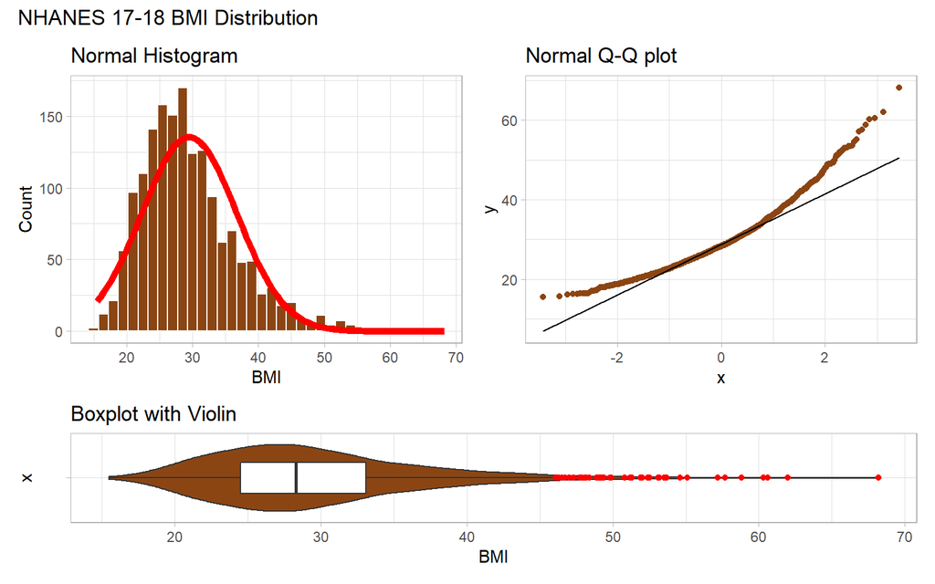

```r
res <- mosaic::favstats(~ BMXBMI, data = study2_train)
bin_w <- 1.5

p1 <- ggplot(study2_train, aes(x = BMXBMI)) +
  geom_histogram(binwidth = bin_w,
                 fill = "chocolate4", col = "white") +
  stat_function(
    fun = function(x) dnorm(x, mean = res$mean,
                            sd = res$sd) *
                  res$n * bin_w,
                col = "red", size = 2) +
  labs(title = "Normal Histogram",
       x = "BMI",
       y = "Count") +
  theme_light()

p2 <- ggplot(study2_train, aes(sample = BMXBMI)) +
  geom_qq(col = "chocolate4") +
  geom_qq_line() +
  labs(title = "Normal Q-Q plot") +
  theme_light()

p3 <- ggplot(study2_train, aes(x = "", y = BMXBMI)) +
  geom_violin (fill = "chocolate4") +
  geom_boxplot(width = .425,
               outlier.color = "red") +
  coord_flip() +
  labs(title = "Boxplot with Violin",
       y = "BMI") +
  theme_light()

p1 + p2 - p3 + plot_layout(ncol = 1, height = c(3,1)) +
  plot_annotation(title = "NHANES 17-18 BMI Distribution")
```

Based on the visualization above, there appears to be a noticeable right skew. My initial thoughts are that a transformation of the outcome should be considered. Outliers do not seem to problematic to where a transformation can’t fix normality. My Initial thoughts are that a log transformation may work out okay, however I will confirm these results later within the model using a boxCox plot.

## 6.2 Numerical Summary of Normal Outcome

```r
res
```

```
  min   Q1 median   Q3  max    mean       sd    n missing
 15.5 24.5   28.3 33.1 68.2 29.4978 7.213298 1634       0
```

## 6.3 Visualize Outcome Transformation

Below is a visualization of the transformation that was settled upon for the outcome. The boxCox plot actually recommends the inverse of the square root of the outcome, however I opted against this transformation because the results are almost uninterpretable within the regression model. Instead I looked at the log transformation, and I feel that it does not violate normality too much. There are a few outliers, however they are not very extreme, so I am going to keep this transformation and assume normality of the outcome.

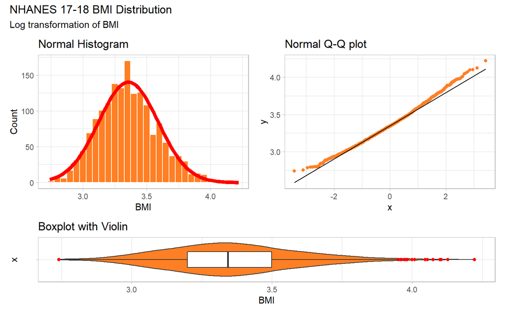

```r
res <- mosaic::favstats(~ log(BMXBMI), data = study2_train)
bin_w <- 0.05

p1 <- ggplot(study2_train, aes(x = log(BMXBMI))) +
  geom_histogram(binwidth = bin_w,
                 fill = "chocolate1", col = "white") +
  stat_function(
    fun = function(x) dnorm(x, mean = res$mean,
                            sd = res$sd) *
                  res$n * bin_w,
                col = "red", size = 2) +
  labs(title = "Normal Histogram",
       x = "BMI",
       y = "Count") +
  theme_light()

p2 <- ggplot(study2_train, aes(sample = log(BMXBMI))) +
  geom_qq(col = "chocolate1") +
  geom_qq_line() +
  labs(title = "Normal Q-Q plot") +
  theme_light()

p3 <- ggplot(study2_train, aes(x = "", y = log(BMXBMI))) +
  geom_violin (fill = "chocolate1") +
  geom_boxplot(width = .425,
               outlier.color = "red") +
  coord_flip() +
  labs(title = "Boxplot with Violin",
       y = "BMI") +
  theme_light()

p1 + p2 - p3 + plot_layout(ncol = 1, height = c(3,1)) +
  plot_annotation(title = "NHANES 17-18 BMI Distribution",
                  subtitle = "Log transformation of BMI")
```

## 6.4 Numerical Summary of Transformed Outcome

Transformed numerical summary shows that the largest residual is about 3.5. This aids in the idea that the outliers are not very problematic.

```r
res %>% kable (digits = 3)
```

|  | min | Q1 | median | Q3 | max | mean | sd | n | missing |
| --- | --- | --- | --- | --- | --- | --- | --- | --- | --- |
|  | 2.741 | 3.199 | 3.343 | 3.5 | 4.222 | 3.357 | 0.233 | 1634 | 0 |

## 6.5 Numerical Summary of Predictors

Below is a numerical summary of the predictors. These are separated into two tables, where one shows the two categorical variables and one shows the three quantitative predictors. The first table shows the number of levels and the distribution of the levels, with the second table showing a numerical summary of the distributions. All values appear reasonable and distribution of categories looks okay.

```r
study2_train %>% select(-SEQN, -RIDSTATR, - RIDAGEYR, -BMXBMI) %>%
  mosaic::inspect()
```

```
categorical variables:
      name  class levels    n missing
1   OCQ670 factor      4 1634       0
2 INDHHIN2 factor      4 1634       0
                                   distribution
1 9-5 (36.7%), Varied (35.7%) ...
2 Highest (38.1%), Low (25.9%) ...

quantitative variables:
       name   class min  Q1 median  Q3  max       mean         sd    n missing
...1 OCQ180 numeric   5  35     40  47   80  40.117503  13.896420 1634       0
...2 DBD895 numeric   0   1      3   5   21   4.113831   4.202092 1634       0
...3 CBD071 numeric   0 214    400 600 8400 441.677479 373.219894 1634       0
```

## 6.6 Scatter Plot Matrix

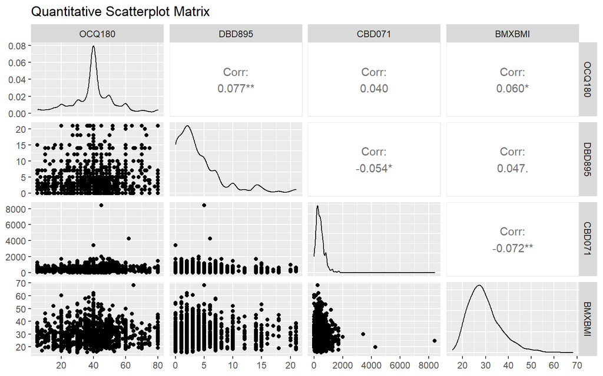

```r
study2_train %>%
  select(OCQ180, DBD895, CBD071, BMXBMI) %>%
  ggpairs(., title = "Quantitative Scatterplot Matrix",
          lower = list(combo = wrap("facethist", bins = 10)))
```

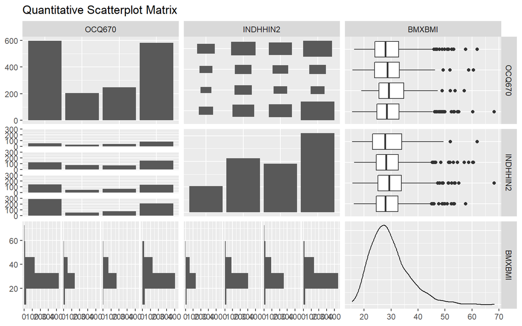

```r
study2_train %>%
  select(OCQ670, INDHHIN2, BMXBMI) %>%
  ggpairs(., title = "Quantitative Scatterplot Matrix",
          lower = list(combo = wrap("facethist", bins = 5)))
```

To aid in assessing the categorical variables, numerical summaries are shown fo the outcome across group levels of a categorical variable. Across `OCQ670`, `BMXBMI` distribution appears very similar, and all groups show a meaningful number of observations.

```r
mosaic::favstats(BMXBMI ~ OCQ670, data = study2_train)
```

```
    OCQ670  min   Q1 median    Q3  max     mean       sd   n missing
1      9-5 16.3 24.0   27.9 32.75 62.0 29.13806 7.053578 599       0
2   Nights 15.7 23.8   28.6 33.10 60.6 29.14293 7.333265 205       0
3 Mornings 18.9 25.5   29.2 34.75 57.2 30.36680 6.662426 247       0
4   Varied 15.5 24.7   28.4 33.00 68.2 29.62401 7.533021 583       0
```

The table below shows `BMXBMI` distribution across `INDHHIN2` categories. The highest median and mean values are seen for the High category, however this is a very small difference from the next largest. Nothing seems to be of concern when looking at these numerical distributions.

```r
mosaic::favstats(BMXBMI ~ INDHHIN2, data = study2_train)
```

```
  INDHHIN2  min    Q1 median     Q3  max     mean       sd   n missing
1   Lowest 15.5 23.05  27.80 33.900 62.0 28.81981 7.650677 207       0
2      Low 16.3 24.50  28.20 32.700 60.6 29.57045 7.321438 423       0
3     High 15.7 25.10  29.25 33.875 68.2 30.40314 7.533930 382       0
4  Highest 16.2 24.50  27.90 32.575 57.7 29.11801 6.734376 622       0
```

## 6.7 BoxCox Plot

Using the model with all five predictors, performed a boxCox test to see whether a transformation is necessary for the outcome. The plot below recommends the inverse of the square root as a transformation, however this makes it very difficult to interpret so instead I will consider the log transformation. Since I kept the transformation, the visualization and discussion is above in the section on the outcome.

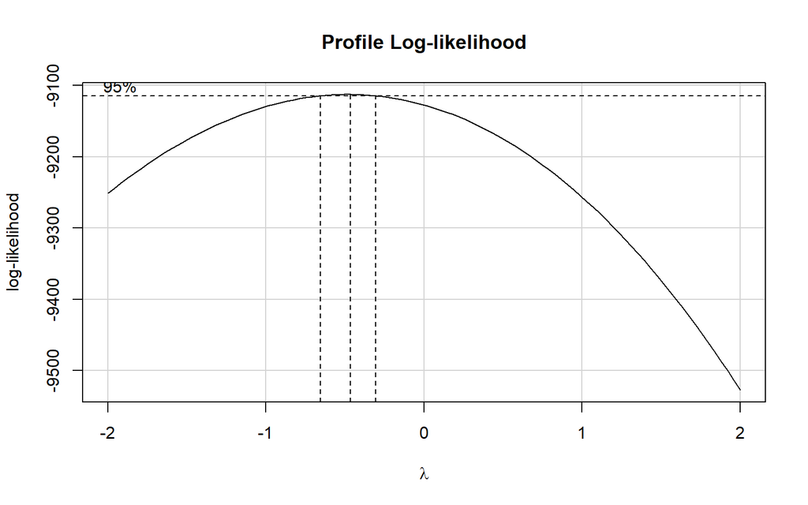

```r
boxCox(lm(BMXBMI~OCQ180+OCQ670+DBD895+CBD071+INDHHIN2, data = study2_train))
```

# 7 The Big Model

## 7.1 Fitting and Summarizing Big Model

The first model that I’m going to look at fits all five predictors. This model (the ‘big’ model) will be compared later against a smaller model in predicting the test data set.

```r
model1<-lm(log(BMXBMI) ~ OCQ180+OCQ670+DBD895+CBD071+INDHHIN2, data = study2_train)
```

## 7.2 Effect Sizes: Coefficient Estimates

Below is a tidy table showing coefficients and 90% confidence intervals for the big model. Estimate for this model is the predicted log of BMI when all other variables are 0. Estimates for quantitative variables are read as a slope, where each 1 change in *x* increases or decreases the log of BMI by the slope amount. Each estimate for the categorical variables is an addition or subtraction to the log of the BMI when they belong to that category.

```r
tidy(model1, conf.int = TRUE, conf.level = 0.90) %>%
  select(term, estimate, std.error, conf.low, conf.high, p.value) %>%
  kable(dig = 5)
```

| term | estimate | std.error | conf.low | conf.high | p.value |
| --- | --- | --- | --- | --- | --- |
| (Intercept) | 3.27886 | 0.02461 | 3.23835 | 3.31937 | 0.00000 |
| OCQ180 | 0.00112 | 0.00042 | 0.00043 | 0.00181 | 0.00745 |
| OCQ670Nights | -0.00061 | 0.01894 | -0.03178 | 0.03056 | 0.97421 |
| OCQ670Mornings | 0.04617 | 0.01763 | 0.01715 | 0.07519 | 0.00891 |
| OCQ670Varied | 0.01071 | 0.01353 | -0.01156 | 0.03299 | 0.42874 |
| DBD895 | 0.00234 | 0.00137 | 0.00008 | 0.00461 | 0.08824 |
| CBD071 | -0.00004 | 0.00002 | -0.00007 | -0.00002 | 0.00875 |
| INDHHIN2Low | 0.03266 | 0.01962 | 0.00036 | 0.06496 | 0.09625 |
| INDHHIN2High | 0.05978 | 0.02006 | 0.02677 | 0.09280 | 0.00293 |
| INDHHIN2Highest | 0.02108 | 0.01902 | -0.01023 | 0.05238 | 0.26807 |

## 7.3 Big Model Equation Description

Below is the full extracted equation of the big model, with the log of BMI as the outcome.

```r
extract_eq(model1, use_coefs = TRUE, coef_digits = 3,
           terms_per_line = 3, wrap = TRUE, ital_vars = TRUE)
```

$$\begin{aligned}
\widehat{log(BMXBMI)} &= 3.279 + 0.001(OCQ180) - 0.001(OCQ670_{Nights})\ + \\
&\quad 0.046(OCQ670_{Mornings}) + 0.011(OCQ670_{Varied}) + 0.002(DBD895)\ + \\
&\quad 0(CBD071) + 0.033(INDHHIN2_{Low}) + 0.06(INDHHIN2_{High})\ + \\
&\quad 0.021(INDHHIN2_{Highest})
\end{aligned}$$

This model reads that with all other quantitative variables kept at 0, the individual working 9-5, and belonging in the lowest income category, the log of BMI will be 3.28 . For every 1 increase in `OCQ180`, the log of BMI increases by 0.001. When belonging to the `OCQ670` group of ‘morning’ or ‘varied, the log of BMI will increase, and `OCD670` group ’nights’ will decrease the log of BMI. As `DBD895` increases, the log of BMI will increase, while the log of BMI will decrease as `CBD071` increases. Lastly, All other groups for `INDHHIN2` increase the log of BMI when compared to the ‘lowest’ group. All of these comparisons for the coefficients are interpretted when holding all other predictors constant.

# 8 Smaller Model

## 8.1 Backwards Stepwise Elimination

In an attempt to determine a better fit model, a backwards stepwise elimination was ran.

```r
step(model1)
```

```
Start:  AIC=-4784.6
log(BMXBMI) ~ OCQ180 + OCQ670 + DBD895 + CBD071 + INDHHIN2

           Df Sum of Sq    RSS     AIC
<none>                  86.349 -4784.6
- DBD895    1   0.15471 86.503 -4783.7
- OCQ670    3   0.40007 86.749 -4783.1
- INDHHIN2  3   0.57413 86.923 -4779.8
- CBD071    1   0.36639 86.715 -4779.7
- OCQ180    1   0.38166 86.730 -4779.4
```

```
Call:
lm(formula = log(BMXBMI) ~ OCQ180 + OCQ670 + DBD895 + CBD071 +
    INDHHIN2, data = study2_train)

Coefficients:
    (Intercept)           OCQ180     OCQ670Nights   OCQ670Mornings
      3.279e+00        1.120e-03       -6.122e-04        4.617e-02
   OCQ670Varied           DBD895           CBD071      INDHHIN2Low
      1.071e-02        2.344e-03       -4.069e-05        3.266e-02
   INDHHIN2High  INDHHIN2Highest
      5.978e-02        2.108e-02
```

## 8.2 Fitting Small Model

The smaller model fit will only use the key predictor. This is the variable `CBD071`, or the amount of money spent at the supermarket/grocery store in the last 30 days.

```r
model2 <- lm(log(BMXBMI) ~ CBD071, data = study2_train)
```

## 8.3 Effect Sizes: Coefficient Estimates

```r
tidy(model2, conf.int = TRUE, conf.level = 0.90) %>%
  select(term, estimate, std.error, conf.low, conf.high, p.value) %>%
  kable(dig = 5)
```

| term | estimate | std.error | conf.low | conf.high | p.value |
| --- | --- | --- | --- | --- | --- |
| (Intercept) | 3.37436 | 0.00890 | 3.35972 | 3.38901 | 0.00000 |
| CBD071 | -0.00004 | 0.00002 | -0.00007 | -0.00001 | 0.00917 |

## 8.4 Describing Small Model Equation

```r
extract_eq(model2, use_coefs = TRUE, coef_digits = 5,
           terms_per_line = 3, wrap = TRUE, ital_vars = TRUE)
```

$$\begin{aligned}
\widehat{log(BMXBMI)} &= 3.37436 - 4e-05(CBD071)
\end{aligned}$$

For every increase in dollar spent at the supermarket, the estimated log of BMI decreases by 4e^5. If spending 0 dollars at the supermarket, the estimated log of BMI is 3.38.

# 9 In-Sample Comparison

In this section, I am going to compare the big model to the small model through assessing how well it fits the smaller test data that was partitioned from the original data set.

## 9.1 Quality of Fit

Each model is going to be compared on their fit quality through AIC, BIC, and adjusted r.squared. In order to do this, I need to create a glance table for the two models and bind them together for comparison.

```r
temp1 <- glance(model1) %>%
  select(-logLik, -deviance) %>%
  mutate(modelname = "large")

temp2 <- glance(model2) %>%
  select(-logLik, -deviance) %>%
  mutate(modelname = "small")

training_comp <- bind_rows(temp1, temp2) %>%
  select(modelname, nobs, df, AIC, BIC, everything())
```

```r
training_comp
```

```
# A tibble: 2 x 11
  modelname  nobs    df   AIC    BIC r.squared adj.r.squared sigma statistic
  <chr>     <int> <dbl> <dbl>  <dbl>     <dbl>         <dbl> <dbl>     <dbl>
1 large      1634     9 -146.  -86.1   0.0220        0.0166  0.231      4.06
2 small      1634     1 -132. -116.    0.00415       0.00354 0.232      6.81
# ... with 2 more variables: p.value <dbl>, df.residual <int>
```

## 9.2 Assessing Assumptions

Here I am using the `augment` function to create residual plots.

```r
aug1 <- augment(model1, data = study2_train)

aug2 <- augment(model2, data = study2_train)
```

### 9.2.1 Model 1 Residual Analysis

Code below generates residual plots for the big model. The plots were created using ggplot and patchwork to combine them into one visualization.

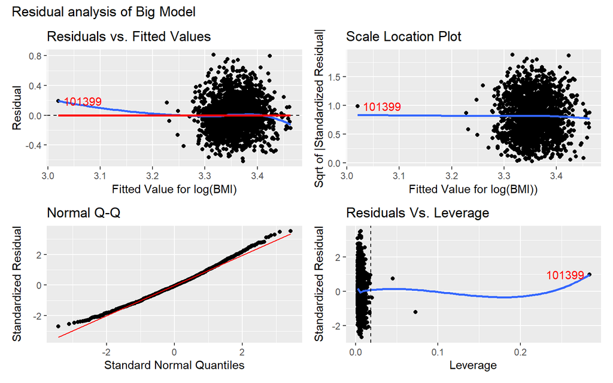

```r
p1 <- ggplot(aug1, aes(x = .fitted, y = .resid)) +
  geom_point() +
  geom_abline(intercept = 0, slope = 0, lty = "dashed") +
  geom_smooth(method = "loess", formula = y ~ x, se = FALSE) +
  geom_smooth(method = "lm", formula = y ~ x, col = "red", se = FALSE) +
  geom_text_repel(data=aug1 %>% filter(.hat > 0.2),
                  aes(label = SEQN), col = "red") +
  labs(title = "Residuals vs. Fitted Values",
       x = "Fitted Value for log(BMI)",
       y = "Residual")

p2 <- ggplot(aug1, aes(x = .fitted, y = sqrt(abs(.std.resid)))) +
  geom_point() +
  geom_smooth(method = "loess", formula = y ~ x, span = 2, se = F) +
  geom_text_repel(data=aug1 %>% filter(.hat > 0.2),
                  aes(label = SEQN), col = "red") +
  labs(title = "Scale Location Plot",
       x = "Fitted Value for log(BMI))",
       y = "Sqrt of |Standardized Residual|")

p3 <- ggplot(aug1, aes(sample = .std.resid)) +
  geom_qq() +
  geom_qq_line(col = "red") +
  labs(title = "Normal Q-Q",
       x = "Standard Normal Quantiles",
       y = "Standardized Residual")

p4 <- ggplot(aug1, aes(x =.hat, y = .std.resid)) +
  geom_point() +
  geom_smooth(method = "loess", formula = y ~ x, se = F) +
  geom_vline(aes(xintercept = 3*mean(.hat)), lty="dashed") +
  geom_text_repel(data=aug1 %>% filter(.hat > 0.2),
                  aes(label = SEQN), col = "red") +
  labs(title = "Residuals Vs. Leverage",
       x = "Leverage", y = "Standardized Residual")

p1 + p2 + p3 + p4 + plot_annotation(title = "Residual analysis of Big Model")
```

The code above generates four residual plots to assess the regression assumptions. Plots created include the residuals vs. fitted values, scale location plot, normal q-q plot, and residuals vs. leverage. The residual vs. fitted plot appears to not have any distinct pattern, so I don’t see any serious problems with non-linearity. The scale location plot looks good, with no clear reasons to think there is non-constant variance. The normal q-q plot fits well, and lastly we look at the residuals vs. leverage plot. There is one point with an unusually large leverage compared to the rest, so I identified it by SEQN number.

### 9.2.2 Model 2 Residual Analysis

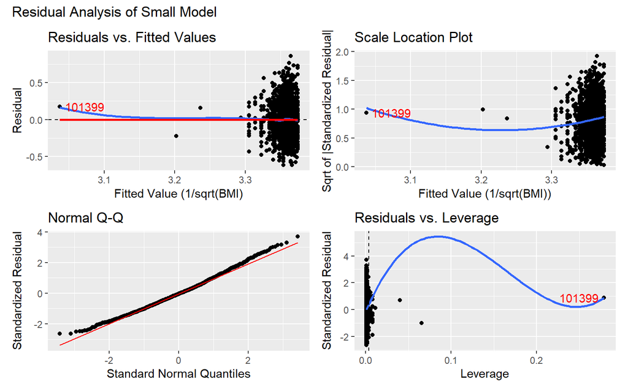

```r
p1 <- ggplot(aug2, aes(x = .fitted, y = .resid)) +
  geom_point() +
  geom_abline(intercept = 0, slope = 0, lty = "dashed") +
  geom_smooth(method = "loess", formula = y ~ x, se = FALSE) +
  geom_smooth(method = "lm", formula = y ~ x, col = "red", se = FALSE) +
  geom_text_repel(data=aug2 %>% filter(.hat > 0.2),
                  aes(label = SEQN), col = "red") +
  labs(title = "Residuals vs. Fitted Values",
       x = "Fitted Value (1/sqrt(BMI)",
       y = "Residual")

p2 <- ggplot(aug2, aes(x = .fitted, y = sqrt(abs(.std.resid)))) +
  geom_point() +
  geom_smooth(method = "loess", formula = y ~ x, span = 2, se = F) +
  geom_text_repel(data=aug2 %>% filter(.hat > 0.2),
                  aes(label = SEQN), col = "red") +
  labs(title = "Scale Location Plot",
       x = "Fitted Value (1/sqrt(BMI))",
       y = "Sqrt of |Standardized Residual|")

p3 <- ggplot(aug2, aes(sample = .std.resid)) +
  geom_qq() +
  geom_qq_line(col = "red") +
  labs(title = "Normal Q-Q",
       x = "Standard Normal Quantiles",
       y = "Standardized Residual")


p4 <- ggplot(aug2, aes(x =.hat, y = .std.resid)) +
  geom_point() +
  geom_smooth(method = "loess", formula = y ~ x, se = F) +
  geom_vline(aes(xintercept = 3*mean(.hat)), lty="dashed") +
  geom_text_repel(data=aug2 %>% filter(.hat > 0.2),
                  aes(label = SEQN), col = "red") +
  labs(title = "Residuals vs. Leverage",
       x = "Leverage", y = "Standardized Residual")


p1 + p2 + p3 + p4 + plot_annotation(title = "Residual Analysis of Small Model")
```

The residual assessment for model 2 is shown above as well. In all plots except the normal q-q plot, a specific value can be seen with a much lower fitted value, but it is actually fit okay. In the residual vs. fitted value plot, This model may have problems with constant variance, where it appears that variance increases as fitted values increase. The unusual observation with high levrage has also been identified by the SEQN (sequence ID).

### 9.2.3 Identifying large leverage point

Residual plots from both models above show a point with unusually large leverage. Although I am unsure whether I would be just in removing the point from analysis, I would at least like to identify and investigate it.

```r
aug1 %>%
  filter(SEQN == 101399)
```

```
# A tibble: 1 x 15
  SEQN     RIDAGEYR RIDSTATR BMXBMI OCQ180 OCQ670 DBD895 CBD071 INDHHIN2 .fitted
  <labell>    <dbl> <fct>     <dbl>  <dbl> <fct>   <dbl>  <dbl> <fct>      <dbl>
1 101399         41 2          24.8     45 9-5         5   8400 Highest     3.02
# ... with 5 more variables: .resid <dbl>, .hat <dbl>, .sigma <dbl>,
#   .cooksd <dbl>, .std.resid <dbl>
```

# 10 Model Validation

## 10.1 Prediction Errors

### 10.1.1 Model1 Back-Transformation

```r
aug1 <- augment(model1, newdata = study2_train) %>%
  mutate(mod_name = "big",
         bmi_fit = exp(.fitted),
         bmi_res = BMXBMI - bmi_fit) %>%
  select(SEQN, mod_name, BMXBMI, bmi_fit, bmi_res, everything())

head(aug1, 5)
```

```
# A tibble: 5 x 14
  SEQN    mod_name BMXBMI bmi_fit bmi_res RIDAGEYR RIDSTATR OCQ180 OCQ670 DBD895
  <label> <chr>     <dbl>   <dbl>   <dbl>    <dbl> <fct>     <dbl> <fct>   <dbl>
1 95329   big        24.5    29.2   -4.75       47 2            35 Varied      5
2 94557   big        34.7    29.9    4.77       35 2            75 Varied      3
3 95333   big        31      28.4    2.59       39 2            40 Varied      0
4 99473   big        25.6    29.1   -3.55       41 2            80 Varied      2
5 97210   big        29.8    28.6    1.24       47 2            40 Varied      1
# ... with 4 more variables: CBD071 <dbl>, INDHHIN2 <fct>, .fitted <dbl>,
#   .resid <dbl>
```

### 10.1.2 Model2 Back-Transformation

Same augmentation is applied to second smaller model.

```r
aug2 <- augment(model2, newdata = study2_train) %>%
  mutate(mod_name = "small",
         bmi_fit = exp(.fitted),
         bmi_res = BMXBMI - bmi_fit) %>%
  select(SEQN, mod_name, BMXBMI, bmi_fit, bmi_res, everything())

head(aug2, 5)
```

```
# A tibble: 5 x 14
  SEQN    mod_name BMXBMI bmi_fit bmi_res RIDAGEYR RIDSTATR OCQ180 OCQ670 DBD895
  <label> <chr>     <dbl>   <dbl>   <dbl>    <dbl> <fct>     <dbl> <fct>   <dbl>
1 95329   small      24.5    28.5   -4.01       47 2            35 Varied      5
2 94557   small      34.7    28.8    5.90       35 2            75 Varied      3
3 95333   small      31      28.6    2.37       39 2            40 Varied      0
4 99473   small      25.6    28.3   -2.68       41 2            80 Varied      2
5 97210   small      29.8    28.7    1.09       47 2            40 Varied      1
# ... with 4 more variables: CBD071 <dbl>, INDHHIN2 <fct>, .fitted <dbl>,
#   .resid <dbl>
```

Augmentations of each model are combined into a test comparison table.

```r
test_comp <- union(aug1, aug2) %>%
  arrange (SEQN, mod_name)

test_comp %>% head()
```

```
# A tibble: 6 x 14
  SEQN    mod_name BMXBMI bmi_fit bmi_res RIDAGEYR RIDSTATR OCQ180 OCQ670 DBD895
  <label> <chr>     <dbl>   <dbl>   <dbl>    <dbl> <fct>     <dbl> <fct>   <dbl>
1 93711   big        21.3    27.5   -6.25       56 2            35 9-5         4
2 93711   small      21.3    28.3   -6.98       56 2            35 9-5         4
3 93716   big        30.7    28.1    2.63       61 2            40 9-5         0
4 93716   small      30.7    28.9    1.79       61 2            40 9-5         0
5 93721   big        35.9    28.6    7.27       60 2             5 Varied      1
6 93721   small      35.9    29.1    6.78       60 2             5 Varied      1
# ... with 4 more variables: CBD071 <dbl>, INDHHIN2 <fct>, .fitted <dbl>,
#   .resid <dbl>
```

## 10.2 Prediction Visualization

Code below generates a visualization to compare predictions between the two models.

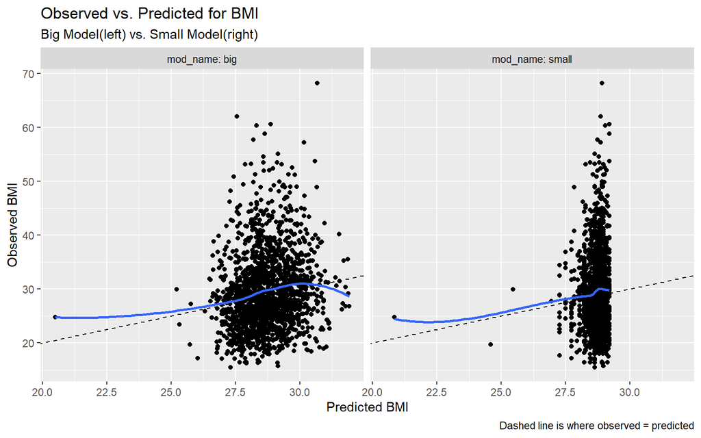

```r
ggplot(test_comp, aes(x = bmi_fit, y = BMXBMI)) +
  geom_point() +
  geom_abline(slope = 1, intercept = 0, lty = "dashed") +
  geom_smooth(method = "loess", formula = y ~ x, se = F) +
  facet_wrap( ~ mod_name, labeller = "label_both") +
  labs(title = "Observed vs. Predicted for BMI",
       subtitle = "Big Model(left) vs. Small Model(right)",
       x = "Predicted BMI",
       y = "Observed BMI",
       caption = "Dashed line is where observed = predicted")
```

The visualization above shows a large discrepancy in the observed vs. predicted values for BMI between the two models. Since the smaller model only consists of one predictor with a negative slope, there is a very strict cut off point for maximum fitted BMI values.

Visualization below also looks at distribution of errors between each model.

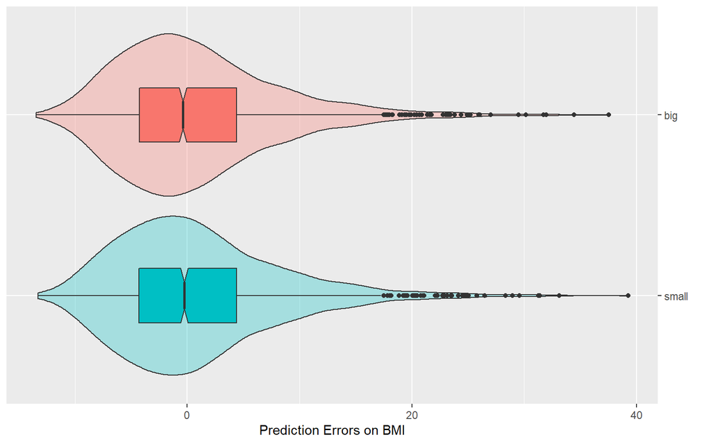

```r
ggplot(test_comp, aes(x = factor(mod_name), y = bmi_res, fill = mod_name)) +
  geom_violin(alpha = 0.3) +
  geom_boxplot(width = 0.3, notch = TRUE) +
  scale_x_discrete(position = "top",
                   limits =
                     rev(levels(factor(test_comp$mod_name)))) +
  guides(fill = "none") +
  coord_flip() +
  labs(x = "",
       y = "Prediction Errors on BMI")
```

However, distribution of errors for each model appear the same.

## 10.3 Summarizing Errors

Code below generates a table to summarize the errors for each model. These values will be meaningful in judging the quality of predictions on BMI made for each model. With each summary statistic, a lower value indicates lower prediction error, which means the model is better predictions. However, when looking at these values, they are almost identical across models. the big model displays slightly smaller MAPE, RMSPE, and max error.

```r
test_comp %>%
  group_by(mod_name) %>%
  summarize(n = n(),
            MAPE = mean(abs(bmi_res)),
            RMSPE = sqrt(mean(bmi_res^2)),
            max_error = max(abs(bmi_res)))
```

```
# A tibble: 2 x 5
  mod_name     n  MAPE RMSPE max_error
  <chr>    <int> <dbl> <dbl>     <dbl>
1 big       1634  5.40  7.18      37.5
2 small     1634  5.44  7.24      39.3
```

## 10.4 Largest Errors

```r
temp1 <- aug1 %>%
  filter(abs(bmi_res) == max(abs(bmi_res)))

temp2 <- aug2 %>%
  filter(abs(bmi_res) == max(abs(bmi_res)))

bind_rows(temp1,temp2)
```

```
# A tibble: 2 x 14
  SEQN    mod_name BMXBMI bmi_fit bmi_res RIDAGEYR RIDSTATR OCQ180 OCQ670 DBD895
  <label> <chr>     <dbl>   <dbl>   <dbl>    <dbl> <fct>     <dbl> <fct>   <dbl>
1 102560  big        68.2    30.7    37.5       33 2            65 Varied      5
2 102560  small      68.2    28.9    39.3       33 2            65 Varied      5
# ... with 4 more variables: CBD071 <dbl>, INDHHIN2 <fct>, .fitted <dbl>,
#   .resid <dbl>
```

## 10.5 R-square for Test Sample

```r
aug1 %$% cor(BMXBMI, bmi_fit)^2
```

```
[1] 0.01943519
```

```r
aug2 %$% cor(BMXBMI, bmi_fit)^2
```

```
[1] 0.005366379
```

# 11 Discussion

## 11.2 Research Question Answer

Based on the large model, I do not think we are able to accurately predict BMI values based on the amount of money spent at the supermarket/grocery store, even when account for work and economic factors.

## 11.3 Next Steps

Another step that I would like to take this is by looking at different variables that relate to work factors. I also think it would be worth accounting for different confounders, such as age or US region that they live in. I think it would be extremely difficult to find a model that accounts for a large amount of variance in BMI values, however I do think there are better fit models out there. I would still like to look at how work pressures in the US affect an individuals overall health.

## 11.4 Reflection

With what I know, I would have changed my approach to study 2 by looking at the NHANES data and developing a focused research question. Developing a research question that is interpretable is difficult when you incorporate multiple variables that are seemingly unrelated. My original thoughts included more variables relating to nutritional knowledge and it felt difficult to develop a research question that I liked while including occupational variables. I also wouldn’t be opposed to including variables that I could reasonably see are confounders. I think I tend to have a predisposition to like smaller models, and this analysis gave me insight as to why a simpler model is not always better to use.